# Actividad Grupo 4 - Análisis Series de Tiempo

Andrés Monsalve, Luz Angélica Norato y Willy Corzo

2024-10-13

# Actividad 1 - Descripción de la Base de Datos

Inicialmente, la base de datos incluye un total de 475 ítems. Sin embargo, tras realizar un análisis exhaustivo, hemos decidido concentrarnos en los primeros 80 ítems, ya que estos representan el 90.24% de las ventas totales registradas en el año 2023. Además, la base de datos proporciona información sobre siete puntos de acogida de inventario de la empresa, pero para los objetivos de esta clase, nos limitaremos a utilizar únicamente el total de las ventas.

```r
#leer datos
data <- read.csv("Ventas_t.csv",header = TRUE, sep = ";")

data$Fecha <- as.Date(data$Fecha, format = "%d/%m/%Y")


head(data)
```

|  | Fecha | Item.1 | Item.2 | Item.3 | Item.4 | Item.5 | Item.6 | Item.7 | Item.8 | Item.9 | Item.10 | Item.11 | Item.12 | Item.13 | Item.14 | Item.15 | Item.16 | Item.17 | Item.18 | Item.19 | Item.20 | Item.21 | Item.22 | Item.23 | Item.24 | Item.25 | Item.26 | Item.27 | Item.28 | … |
| --- | --- | --- | --- | --- | --- | --- | --- | --- | --- | --- | --- | --- | --- | --- | --- | --- | --- | --- | --- | --- | --- | --- | --- | --- | --- | --- | --- | --- | --- | --- |
| 1 | 2021-01-10 | 884 | 716 | 548 | 1 | 4 | 50 | 4 | 7 | 52 | 708 | 18 | 0 | 42 | 64 | 224 | 0 | 45 | 0 | 0 | 7 | 17 | 6 | 1 | 0 | 0 | 0 | 0 | 0 | … |
| 2 | 2021-01-17 | 3150 | 3400 | 2166 | 0 | 14 | 55 | 18 | 40 | 70 | 1788 | 352 | 5 | 0 | 8 | 166 | 34 | 131 | 0 | 2 | 14 | 2 | 121 | 0 | 30 | 0 | 12 | 0 | 0 | … |
| 3 | 2021-01-24 | 0 | 0 | 5 | 7 | 1 | 14 | 13 | 9 | 13 | 0 | 136 | 0 | 88 | 0 | 15 | 60 | 36 | 0 | 1 | 0 | 2 | 0 | 0 | 0 | 0 | 24 | 0 | 0 | … |
| 4 | 2021-01-31 | 4296 | 3596 | 2902 | 1 | 43 | 139 | 3 | 47 | 78 | 400 | 328 | 10 | 40 | 10 | 91 | 20 | 35 | 0 | 0 | 24 | 0 | 90 | 0 | 200 | 0 | 159 | 0 | 0 | … |
| 5 | 2021-02-07 | 0 | 0 | 0 | 0 | 0 | 25 | 0 | 0 | 17 | 0 | 128 | 0 | 34 | 0 | 27 | 0 | 0 | 0 | 0 | 0 | 0 | 15 | 0 | 150 | 0 | 55 | 0 | 0 | … |
| 6 | 2021-02-14 | 1336 | 2060 | 1396 | 9 | 40 | 60 | 0 | 0 | 34 | 792 | 4 | 13 | 44 | 16 | 73 | 0 | -1 | 0 | 0 | 0 | 0 | 0 | 1 | 200 | 0 | 0 | 0 | 4 | … |

El propósito de trabajar con esta base de datos es llevar a cabo predicciones de ventas, considerando diversos factores temporales. Esto implica un análisis de patrones estacionales, tendencias históricas y otros elementos temporales que pueden influir en el comportamiento de las ventas.

Un desafío significativo que presenta nuestra base de datos es la elevada cantidad de ceros, dado que la empresa se enfoca principalmente en la venta a mayoristas, lo que significa que no todos los ítems generan ventas de forma semanal. Este aspecto deberá ser considerado al aplicar técnicas de análisis de series de tiempo, ya que puede afectar la precisión de los modelos predictivos.

A través de este análisis, se busca no solo comprender mejor las dinámicas de ventas de la empresa, sino también desarrollar habilidades en el manejo y la interpretación de series temporales en un contexto práctico.

# Actividad 2 - Estructura de los datos en series de tiempo

## Entendimiento de los Datos

```r
skim(data)
```

Data summary

| Name | data |
| --- | --- |
| Number of rows | 174 |
| Number of columns | 81 |
| _______________________ |  |
| Column type frequency: |  |
| Date | 1 |
| numeric | 80 |
| ________________________ |  |
| Group variables | None |

**Variable type: Date**

| skim_variable | n_missing | complete_rate | min | max | median | n_unique |
| --- | --- | --- | --- | --- | --- | --- |
| Fecha | 0 | 1 | 2021-01-10 | 2024-05-01 | 2022-09-07 | 174 |

**Variable type: numeric**

| skim_variable | n_missing | complete_rate | mean | sd | p0 | p25 | p50 | p75 | p100 | hist |
| --- | --- | --- | --- | --- | --- | --- | --- | --- | --- | --- |
| Item.1 | 0 | 1 | 1065.86 | 911.30 | -228 | 365.00 | 907.0 | 1497.50 | 4296 | ▇▇▂▁▁ |
| Item.2 | 0 | 1 | 1149.38 | 882.85 | -555 | 507.75 | 989.5 | 1794.00 | 4108 | ▅▇▅▁▁ |
| Item.3 | 0 | 1 | 903.09 | 748.48 | -704 | 346.00 | 720.0 | 1356.75 | 3692 | ▂▇▅▁▁ |
| Item.4 | 0 | 1 | 8.62 | 13.94 | -1 | 1.00 | 4.0 | 8.00 | 84 | ▇▁▁▁▁ |
| Item.5 | 0 | 1 | 25.08 | 26.91 | -57 | 6.00 | 17.5 | 40.75 | 136 | ▁▇▅▁▁ |
| Item.6 | 0 | 1 | 80.07 | 105.41 | -34 | 10.00 | 53.5 | 116.75 | 890 | ▇▁▁▁▁ |
| Item.7 | 0 | 1 | 7.28 | 8.84 | -6 | 2.00 | 5.0 | 10.00 | 59 | ▇▃▁▁▁ |
| Item.8 | 0 | 1 | 13.94 | 17.54 | -30 | 0.00 | 8.5 | 21.75 | 88 | ▁▇▂▁▁ |
| Item.9 | 0 | 1 | 46.70 | 82.55 | -190 | 3.00 | 28.0 | 69.75 | 819 | ▅▇▁▁▁ |
| Item.10 | 0 | 1 | 860.25 | 1405.21 | -3168 | 51.75 | 399.0 | 1081.50 | 7178 | ▁▇▂▁▁ |
| Item.11 | 0 | 1 | 348.18 | 577.07 | -650 | 0.00 | 110.0 | 458.50 | 3444 | ▇▅▁▁▁ |
| Item.12 | 0 | 1 | 16.09 | 17.85 | -11 | 4.00 | 10.0 | 22.75 | 93 | ▇▆▂▁▁ |
| Item.13 | 0 | 1 | 26.29 | 27.85 | -12 | 6.25 | 19.5 | 40.00 | 153 | ▇▅▁▁▁ |
| Item.14 | 0 | 1 | 9.62 | 11.57 | -3 | 1.00 | 5.0 | 14.00 | 64 | ▇▃▁▁▁ |
| Item.15 | 0 | 1 | 100.56 | 133.60 | -84 | 6.50 | 65.0 | 140.25 | 1010 | ▇▂▁▁▁ |
| Item.16 | 0 | 1 | 12.93 | 20.28 | -5 | 0.00 | 5.5 | 17.00 | 157 | ▇▁▁▁▁ |
| Item.17 | 0 | 1 | 41.16 | 62.97 | -3 | 0.00 | 21.5 | 54.50 | 522 | ▇▁▁▁▁ |
| Item.18 | 0 | 1 | 237.43 | 533.60 | -490 | 0.00 | 0.0 | 200.00 | 3152 | ▇▂▁▁▁ |
| Item.19 | 0 | 1 | 2.49 | 6.24 | -1 | 0.00 | 0.0 | 2.00 | 43 | ▇▁▁▁▁ |
| Item.20 | 0 | 1 | 6.53 | 9.17 | -1 | 0.00 | 3.5 | 9.75 | 57 | ▇▂▁▁▁ |
| Item.21 | 0 | 1 | 4.86 | 7.31 | -1 | 0.00 | 2.0 | 6.00 | 38 | ▇▂▁▁▁ |
| Item.22 | 0 | 1 | 66.84 | 104.69 | -8 | 3.00 | 30.0 | 80.75 | 715 | ▇▁▁▁▁ |
| Item.23 | 0 | 1 | 0.79 | 1.18 | 0 | 0.00 | 0.0 | 1.00 | 5 | ▇▁▁▁▁ |
| Item.24 | 0 | 1 | 281.24 | 382.34 | -487 | 0.00 | 140.0 | 410.00 | 1910 | ▁▇▂▁▁ |
| Item.25 | 0 | 1 | 1.57 | 6.47 | 0 | 0.00 | 0.0 | 0.00 | 72 | ▇▁▁▁▁ |
| Item.26 | 0 | 1 | 62.80 | 113.73 | -60 | 0.00 | 18.0 | 84.00 | 732 | ▇▂▁▁▁ |
| Item.27 | 0 | 1 | 0.21 | 0.62 | 0 | 0.00 | 0.0 | 0.00 | 5 | ▇▁▁▁▁ |
| Item.28 | 0 | 1 | 4.30 | 7.06 | -12 | 0.00 | 1.0 | 6.00 | 42 | ▁▇▁▁▁ |
| Item.29 | 0 | 1 | 1.25 | 3.50 | 0 | 0.00 | 0.0 | 0.00 | 22 | ▇▁▁▁▁ |
| Item.30 | 0 | 1 | 48.63 | 77.59 | -58 | 0.00 | 24.0 | 71.75 | 555 | ▇▃▁▁▁ |
| Item.31 | 0 | 1 | 6.34 | 16.04 | -6 | 0.00 | 0.0 | 5.00 | 140 | ▇▁▁▁▁ |
| Item.32 | 0 | 1 | 4.68 | 9.26 | -14 | 0.00 | 0.0 | 5.75 | 48 | ▁▇▁▁▁ |
| Item.33 | 0 | 1 | 0.55 | 1.13 | -3 | 0.00 | 0.0 | 1.00 | 7 | ▁▇▁▁▁ |
| Item.34 | 0 | 1 | 8.99 | 14.04 | -4 | 0.00 | 3.0 | 12.00 | 68 | ▇▂▁▁▁ |
| Item.35 | 0 | 1 | 6.49 | 20.64 | 0 | 0.00 | 0.0 | 0.00 | 136 | ▇▁▁▁▁ |
| Item.36 | 0 | 1 | 4.16 | 47.25 | 0 | 0.00 | 0.0 | 0.00 | 620 | ▇▁▁▁▁ |
| Item.37 | 0 | 1 | 11.34 | 50.80 | -40 | 0.00 | 0.0 | 0.00 | 494 | ▇▁▁▁▁ |
| Item.38 | 0 | 1 | 0.38 | 0.79 | -1 | 0.00 | 0.0 | 0.00 | 4 | ▇▂▁▁▁ |
| Item.39 | 0 | 1 | 76.52 | 93.82 | -64 | 5.00 | 48.0 | 109.75 | 520 | ▇▆▁▁▁ |
| Item.40 | 0 | 1 | 6.95 | 77.73 | 0 | 0.00 | 0.0 | 0.00 | 1006 | ▇▁▁▁▁ |
| Item.41 | 0 | 1 | 0.72 | 1.26 | 0 | 0.00 | 0.0 | 1.00 | 9 | ▇▂▁▁▁ |
| Item.42 | 0 | 1 | 10.11 | 21.67 | -30 | 0.00 | 0.0 | 10.00 | 113 | ▁▇▁▁▁ |
| Item.43 | 0 | 1 | 5.26 | 9.08 | -9 | 0.00 | 1.0 | 7.00 | 65 | ▇▃▁▁▁ |
| Item.44 | 0 | 1 | 0.11 | 0.34 | 0 | 0.00 | 0.0 | 0.00 | 2 | ▇▁▁▁▁ |
| Item.45 | 0 | 1 | 391.52 | 1377.21 | -1584 | 0.00 | 0.0 | 0.00 | 10116 | ▇▁▁▁▁ |
| Item.46 | 0 | 1 | 0.20 | 0.57 | 0 | 0.00 | 0.0 | 0.00 | 3 | ▇▁▁▁▁ |
| Item.47 | 0 | 1 | 102.07 | 444.05 | 0 | 0.00 | 0.0 | 0.00 | 5040 | ▇▁▁▁▁ |
| Item.48 | 0 | 1 | 21.63 | 63.82 | -56 | 0.00 | 0.0 | 0.00 | 540 | ▇▁▁▁▁ |
| Item.49 | 0 | 1 | 82.72 | 129.82 | -150 | 0.00 | 32.0 | 107.50 | 820 | ▇▅▂▁▁ |
| Item.50 | 0 | 1 | 0.54 | 1.02 | -1 | 0.00 | 0.0 | 1.00 | 6 | ▇▂▂▁▁ |
| Item.51 | 0 | 1 | 7.74 | 11.29 | -12 | 0.00 | 3.0 | 10.75 | 58 | ▇▆▂▁▁ |
| Item.52 | 0 | 1 | 0.79 | 4.00 | 0 | 0.00 | 0.0 | 0.00 | 40 | ▇▁▁▁▁ |
| Item.53 | 0 | 1 | 0.02 | 0.30 | 0 | 0.00 | 0.0 | 0.00 | 4 | ▇▁▁▁▁ |
| Item.54 | 0 | 1 | 98.39 | 409.43 | -520 | 0.00 | 0.0 | 0.00 | 4000 | ▇▁▁▁▁ |
| Item.55 | 0 | 1 | 100.78 | 431.29 | -384 | 0.00 | 0.0 | 0.00 | 4568 | ▇▁▁▁▁ |
| Item.56 | 0 | 1 | 0.03 | 0.20 | -1 | 0.00 | 0.0 | 0.00 | 1 | ▁▁▇▁▁ |
| Item.57 | 0 | 1 | 0.25 | 0.81 | 0 | 0.00 | 0.0 | 0.00 | 7 | ▇▁▁▁▁ |
| Item.58 | 0 | 1 | 0.09 | 0.42 | 0 | 0.00 | 0.0 | 0.00 | 4 | ▇▁▁▁▁ |
| Item.59 | 0 | 1 | 10.04 | 32.58 | -60 | 0.00 | 0.0 | 0.00 | 200 | ▁▇▁▁▁ |
| Item.60 | 0 | 1 | 1.60 | 3.71 | -3 | 0.00 | 0.0 | 2.00 | 33 | ▇▁▁▁▁ |
| Item.61 | 0 | 1 | 75.40 | 332.16 | -320 | 0.00 | 0.0 | 0.00 | 2840 | ▇▁▁▁▁ |
| Item.62 | 0 | 1 | 92.63 | 154.04 | -200 | 0.00 | 36.5 | 107.50 | 1008 | ▇▆▁▁▁ |
| Item.63 | 0 | 1 | 8.99 | 28.44 | -60 | 0.00 | 0.0 | 0.00 | 150 | ▁▇▁▁▁ |
| Item.64 | 0 | 1 | 2.52 | 16.36 | -1 | 0.00 | 0.0 | 0.00 | 200 | ▇▁▁▁▁ |
| Item.65 | 0 | 1 | 0.13 | 0.48 | 0 | 0.00 | 0.0 | 0.00 | 4 | ▇▁▁▁▁ |
| Item.66 | 0 | 1 | 168.28 | 623.05 | -1584 | 0.00 | 0.0 | 0.00 | 3588 | ▁▇▁▁▁ |
| Item.67 | 0 | 1 | 75.29 | 188.78 | -2 | 0.00 | 0.0 | 39.00 | 1200 | ▇▁▁▁▁ |
| Item.68 | 0 | 1 | 11.51 | 35.96 | -60 | 0.00 | 0.0 | 0.00 | 200 | ▁▇▁▁▁ |
| Item.69 | 0 | 1 | 1.48 | 8.92 | 0 | 0.00 | 0.0 | 0.00 | 96 | ▇▁▁▁▁ |
| Item.70 | 0 | 1 | 5.09 | 25.22 | 0 | 0.00 | 0.0 | 0.00 | 276 | ▇▁▁▁▁ |
| Item.71 | 0 | 1 | 27.82 | 91.13 | -192 | 0.00 | 0.0 | 0.00 | 500 | ▁▇▁▁▁ |
| Item.72 | 0 | 1 | 0.03 | 0.21 | 0 | 0.00 | 0.0 | 0.00 | 2 | ▇▁▁▁▁ |
| Item.73 | 0 | 1 | 0.28 | 0.90 | 0 | 0.00 | 0.0 | 0.00 | 7 | ▇▁▁▁▁ |
| Item.74 | 0 | 1 | 14.74 | 76.97 | -186 | 0.00 | 0.0 | 0.00 | 714 | ▁▇▁▁▁ |
| Item.75 | 0 | 1 | 20.29 | 66.69 | -144 | 0.00 | 0.0 | 0.00 | 360 | ▁▇▁▁▁ |
| Item.76 | 0 | 1 | 0.34 | 1.23 | 0 | 0.00 | 0.0 | 0.00 | 8 | ▇▁▁▁▁ |
| Item.77 | 0 | 1 | 0.02 | 0.18 | 0 | 0.00 | 0.0 | 0.00 | 2 | ▇▁▁▁▁ |
| Item.78 | 0 | 1 | 81.75 | 199.15 | -100 | 0.00 | 0.0 | 0.00 | 1200 | ▇▁▁▁▁ |
| Item.79 | 0 | 1 | 304.83 | 1165.39 | -1920 | 0.00 | 0.0 | 0.00 | 8920 | ▇▁▁▁▁ |
| Item.80 | 0 | 1 | 0.36 | 1.27 | 0 | 0.00 | 0.0 | 0.00 | 13 | ▇▁▁▁▁ |

Al analizar los estadísticos presentados se puede entender que:

1. No existen registros faltantes dentro del data set
2. Existen items con una gran cantidad de registros en 0, se debe pensar en agrupar items por categorías o características similares
3. Dentro de la base de datos se encuentran registros negativos que obedecen a las devoluciones

## Preparación de los Datos

Como se menciono anteriormente sera necesario realizar algunos procedimientos previos antes de comenzar a realizar analisis, dentro de los procedimientos sera necesario realizar una limpieza o imputacion de datos y crear agrupaciones por categorias de items.

Dentro del dataset se encuentran registros negativos que corresponden a devoluciones de productos, nos centraremos en las ventas por lo tanto estos datos seran imputados con ceros por ser considerados anomalos.

```r
#Imputacion de datos negativos que corresponden a devoluciones

ventas = data
ventas[ventas < 0] = 0
ventas
```

| Fecha | Item.1 | Item.2 | Item.3 | Item.4 | Item.5 | Item.6 | Item.7 | Item.8 | Item.9 | Item.10 | Item.11 | Item.12 | Item.13 | Item.14 | Item.15 | Item.16 | Item.17 | Item.18 | Item.19 | Item.20 | Item.21 | Item.22 | Item.23 | Item.24 | Item.25 | Item.26 | Item.27 | Item.28 | Item.29 | … |
| --- | --- | --- | --- | --- | --- | --- | --- | --- | --- | --- | --- | --- | --- | --- | --- | --- | --- | --- | --- | --- | --- | --- | --- | --- | --- | --- | --- | --- | --- | --- |
| 2021-01-10 | 884 | 716 | 548 | 1 | 4 | 50 | 4 | 7 | 52 | 708 | 18 | 0 | 42 | 64 | 224 | 0 | 45 | 0 | 0 | 7 | 17 | 6 | 1 | 0 | 0 | 0 | 0 | 0 | 0 | … |
| 2021-01-17 | 3150 | 3400 | 2166 | 0 | 14 | 55 | 18 | 40 | 70 | 1788 | 352 | 5 | 0 | 8 | 166 | 34 | 131 | 0 | 2 | 14 | 2 | 121 | 0 | 30 | 0 | 12 | 0 | 0 | 0 | … |
| 2021-01-24 | 0 | 0 | 5 | 7 | 1 | 14 | 13 | 9 | 13 | 0 | 136 | 0 | 88 | 0 | 15 | 60 | 36 | 0 | 1 | 0 | 2 | 0 | 0 | 0 | 0 | 24 | 0 | 0 | 0 | … |
| 2021-01-31 | 4296 | 3596 | 2902 | 1 | 43 | 139 | 3 | 47 | 78 | 400 | 328 | 10 | 40 | 10 | 91 | 20 | 35 | 0 | 0 | 24 | 0 | 90 | 0 | 200 | 0 | 159 | 0 | 0 | 0 | … |
| 2021-02-07 | 0 | 0 | 0 | 0 | 0 | 25 | 0 | 0 | 17 | 0 | 128 | 0 | 34 | 0 | 27 | 0 | 0 | 0 | 0 | 0 | 0 | 15 | 0 | 150 | 0 | 55 | 0 | 0 | 0 | … |
| 2021-02-14 | 1336 | 2060 | 1396 | 9 | 40 | 60 | 0 | 0 | 34 | 792 | 4 | 13 | 44 | 16 | 73 | 0 | 0 | 0 | 0 | 0 | 0 | 0 | 1 | 200 | 0 | 0 | 0 | 4 | 0 | … |
| 2021-02-21 | 3444 | 1830 | 1700 | 6 | 6 | 40 | 2 | 14 | 13 | 100 | 342 | 19 | 20 | 0 | 68 | 15 | 26 | 0 | 6 | 0 | 1 | 21 | 2 | 0 | 1 | 20 | 0 | 0 | 0 | … |
| 2021-02-28 | 2054 | 1816 | 1252 | 0 | 9 | 76 | 11 | 30 | 71 | 300 | 556 | 1 | 60 | 0 | 40 | 25 | 55 | 0 | 2 | 1 | 1 | 3 | 1 | 0 | 0 | 162 | 0 | 8 | 0 | … |
| 2021-03-07 | 296 | 1024 | 760 | 0 | 13 | 49 | 6 | 8 | 0 | 156 | 174 | 0 | 25 | 0 | 0 | 0 | 0 | 0 | 0 | 6 | 1 | 0 | 0 | 100 | 0 | 57 | 0 | 2 | 0 | … |
| 2021-03-14 | 1048 | 1504 | 1184 | 16 | 25 | 37 | 21 | 7 | 54 | 3724 | 1230 | 0 | 41 | 1 | 148 | 31 | 5 | 0 | 0 | 2 | 0 | 0 | 0 | 700 | 0 | 120 | 0 | 0 | 0 | … |

[output cut: 164 more lines]

Para la agrupación de los datos se identificarán las categorías de los ítems

**Grupo AVR:** Los siguientes Items se identifican como AVR

[output not shown]

```r
AVR = ventas%>% select(`Fecha`, `Item.10`, `Item.26`, `Item.30`, `Item.39`, `Item.45`, `Item.49`,
                       `Item.55`, `Item.62`, `Item.66`, `Item.79`)

AVR = AVR%>% mutate(Total_AVR = rowSums(select(.,`Item.10`, `Item.26`, `Item.30`, `Item.39`, `Item.45`, `Item.49`,
                       `Item.55`, `Item.62`, `Item.66`, `Item.79`), na.rm = TRUE))
```

**Grupo Data Center:** Dentro de la base de datos solo se identifica como Data Center el Item 53

| **Data_Center** |
| --- |
| Item.53 |

```r
Data_Center = ventas%>% select(`Fecha`, `Item.53`)
Data_Center = Data_Center%>% mutate(Total_Data_Center = rowSums(select(.,`Item.53`), na.rm = TRUE))
```

**Grupo Line UPS:** Los siguientes Items son identificados como line UPS

[output not shown]

```r
Line_UPS = ventas%>% select(`Fecha`, `Item.1`, `Item.2`, `Item.3`, `Item.6`, `Item.9`,
                            `Item.15`, `Item.17`, `Item.22`, `Item.34`, `Item.48`,
                            `Item.51`, `Item.59`, `Item.63`, `Item.68`, `Item.70`,
                            `Item.71`, `Item.75`)

Line_UPS = Line_UPS%>% mutate(Total_Line_UPS = rowSums(select(.,`Item.1`, `Item.2`, `Item.3`, `Item.6`, `Item.9`,
                            `Item.15`, `Item.17`, `Item.22`, `Item.34`, `Item.48`,
                            `Item.51`, `Item.59`, `Item.63`, `Item.68`, `Item.70`,
                            `Item.71`, `Item.75`), na.rm = TRUE))
```

**Grupo Online UPS:** Los siguientes Items son identificados como Online UPS

| **Online UPS** |  |  |  |
| --- | --- | --- | --- |
| Item.4 | Item.5 | Item.7 | Item.8 |
| Item.12 | Item.13 | Item.14 | Item.16 |
| Item.19 | Item.20 | Item.21 | Item.23 |
| Item.25 | Item.27 | Item.28 | Item.29 |
| Item.31 | Item.32 | Item.33 | Item.38 |
| Item.41 | Item.43 | Item.44 | Item.46 |
| Item.50 | Item.56 | Item.57 | Item.58 |
| Item.60 | Item.65 | Item.72 | Item.76 |
| Item.77 | Item.80 |  |  |

```r
Online_UPS = ventas%>% select(`Fecha`, `Item.4`, `Item.5`, `Item.7`, `Item.8`, `Item.12`,
                            `Item.13`, `Item.14`, `Item.16`, `Item.19`, `Item.20`,
                            `Item.21`, `Item.23`, `Item.25`, `Item.27`, `Item.28`,
                            `Item.29`, `Item.31`, `Item.32`, `Item.33`, `Item.38`, `Item.41`,
                            `Item.43`, `Item.44`, `Item.46`, `Item.50`, `Item.56`, `Item.57`,
                            `Item.58`, `Item.60`, `Item.65`, `Item.72`, `Item.76`, `Item.77`,
                            `Item.80`)

Online_UPS = Online_UPS%>% mutate(Total_Online_UPS = rowSums(select(.,`Item.4`, `Item.5`, `Item.7`, `Item.8`,                              `Item.12`,`Item.13`, `Item.14`, `Item.16`, `Item.19`, `Item.20`,
                            `Item.21`, `Item.23`, `Item.25`, `Item.27`, `Item.28`,
                            `Item.29`, `Item.31`, `Item.32`, `Item.33`, `Item.38`, `Item.41`,
                            `Item.43`, `Item.44`, `Item.46`, `Item.50`, `Item.56`, `Item.57`,
                            `Item.58`, `Item.60`, `Item.65`, `Item.72`, `Item.76`, `Item.77`,
                            `Item.80`), na.rm = TRUE))
```

**Grupo Solar:** Los siguientes Items son identificados como Solar

| **Solar** |  |  |  |
| --- | --- | --- | --- |
| Item.36 | Item.52 | Item.69 | Item.74 |

```r
Solar = ventas%>% select(`Fecha`, `Item.36`, `Item.52`, `Item.69`, `Item.74`)

Solar = Solar%>% mutate(Total_Solar = rowSums(select(.,`Item.36`, `Item.52`, `Item.69`, `Item.74`), na.rm = TRUE))
```

**Grupo Storage Battery:** Los siguientes Items son identificados como Storage Battery

| **Storage Battery** |  |  |  |
| --- | --- | --- | --- |
| Item.11 | Item.18 | Item.24 | Item.35 |
| Item.37 | Item.40 | Item.64 | Item.67 |
| Item.78 |  |  |  |

```r
Storage_Battery = ventas%>% select(`Fecha`, `Item.11`, `Item.18`, `Item.24`, `Item.35`, `Item.37`,
                            `Item.40`, `Item.64`, `Item.67`, `Item.78`)

Storage_Battery = Storage_Battery%>% mutate(Total_Storage_Battery = rowSums(select(.,`Item.11`, `Item.18`, `Item.24`, `Item.35`, `Item.37`, `Item.40`, `Item.64`, `Item.67`, `Item.78`), na.rm = TRUE))
```

**Grupo Surge:** Los siguientes Items son identificados como Surge

| **Surge** |  |  |
| --- | --- | --- |
| Item.47 | Item.54 | Item.61 |

```r
Surge = ventas%>% select(`Fecha`, `Item.47`, `Item.54`, `Item.61`)

Surge = Surge%>% mutate(Total_Surge = rowSums(select(.,`Item.47`, `Item.54`, `Item.61`), na.rm = TRUE))
```

**Grupo Accesories:** Los siguientes Items son identificados como Accesories

| **Accesories** |  |
| --- | --- |
| Item.42 | Item.73 |

```r
Accesories = ventas%>% select(`Fecha`, `Item.42`, `Item.73`)

Accesories = Accesories%>% mutate(Total_Accesories = rowSums(select(.,`Item.42`, `Item.73`), na.rm = TRUE))
```

```r
datos_grupo = data.frame(
  Fecha = data$Fecha,
  AVR =AVR$Total_AVR,
  Data_Center = Data_Center$Total_Data_Center,
  Line_UPS = Line_UPS$Total_Line_UPS,
  Online_UPS = Online_UPS$Total_Online_UPS,
  Solar = Solar$Total_Solar,
  Storage_Battery = Storage_Battery$Total_Storage_Battery,
  Surge = Surge$Total_Surge,
  Accesories = Accesories$Total_Accesories
)

head(datos_grupo)
```

|  | Fecha | AVR | Data_Center | Line_UPS | Online_UPS | Solar | Storage_Battery | Surge | Accesories |
| --- | --- | --- | --- | --- | --- | --- | --- | --- | --- |
| 1 | 2021-01-10 | 792 | 0 | 2530 | 205 | 0 | 18 | 0 | 29 |
| 2 | 2021-01-17 | 2455 | 0 | 9293 | 149 | 0 | 382 | 0 | 0 |
| 3 | 2021-01-24 | 341 | 0 | 94 | 191 | 0 | 546 | 0 | 0 |
| 4 | 2021-01-31 | 1842 | 0 | 11269 | 201 | 0 | 1529 | 0 | 0 |
| 5 | 2021-02-07 | 55 | 0 | 85 | 34 | 0 | 1315 | 0 | 2 |
| 6 | 2021-02-14 | 1732 | 0 | 5021 | 129 | 0 | 940 | 3624 | 1 |

```r
skim(datos_grupo)
```

Data summary

| Name | datos_grupo |
| --- | --- |
| Number of rows | 174 |
| Number of columns | 9 |
| _______________________ |  |
| Column type frequency: |  |
| Date | 1 |
| numeric | 8 |
| ________________________ |  |
| Group variables | None |

**Variable type: Date**

| skim_variable | n_missing | complete_rate | min | max | median | n_unique |
| --- | --- | --- | --- | --- | --- | --- |
| Fecha | 0 | 1 | 2021-01-10 | 2024-05-01 | 2022-09-07 | 174 |

**Variable type: numeric**

| skim_variable | n_missing | complete_rate | mean | sd | p0 | p25 | p50 | p75 | p100 | hist |
| --- | --- | --- | --- | --- | --- | --- | --- | --- | --- | --- |
| AVR | 0 | 1 | 2266.04 | 3455.68 | 0 | 328.25 | 1049.0 | 2361.5 | 22821 | ▇▁▁▁▁ |
| Data_Center | 0 | 1 | 0.02 | 0.30 | 0 | 0.00 | 0.0 | 0.0 | 4 | ▇▁▁▁▁ |
| Line_UPS | 0 | 1 | 3596.87 | 2479.48 | 0 | 1770.00 | 3244.5 | 5016.5 | 12196 | ▇▇▅▁▁ |
| Online_UPS | 0 | 1 | 164.93 | 110.93 | 0 | 85.50 | 140.5 | 223.5 | 641 | ▇▇▂▁▁ |
| Solar | 0 | 1 | 22.23 | 90.20 | 0 | 0.00 | 0.0 | 2.0 | 749 | ▇▁▁▁▁ |
| Storage_Battery | 0 | 1 | 1061.67 | 1277.29 | 0 | 114.50 | 649.0 | 1492.0 | 6979 | ▇▂▁▁▁ |
| Surge | 0 | 1 | 280.69 | 1121.84 | 0 | 0.00 | 0.0 | 48.0 | 11880 | ▇▁▁▁▁ |
| Accesories | 0 | 1 | 10.56 | 21.61 | 0 | 0.00 | 0.0 | 10.0 | 113 | ▇▁▁▁▁ |

Después de realizar las respectivas agrupaciones encontramos que de la base de datos solo será posible trabajar con los grupos AVR, Line UPS, Online UPS y Storage battery, estos grupos presentan una suficiente cantidad de datos para realizar los respectivos análisis al trabajar con datos en el tiempo.

Los otros grupos presentan medianas en 0 lo cual indica que por lo menos el 50% de los datos son 0, por esta razón no serán tenidos en cuenta en este estudio.

## Análisis de los datos en el tiempo

### Media móviles

Las ventas de AVR muestran picos pronunciados en ciertos periodos, especialmente en 2021 y 2022. La variabilidad es alta, con ventas que alcanzan valores superiores a 20,000 en algunos momentos.

La media móvil de 7 periodos (roja) suaviza las fluctuaciones, mostrando una tendencia general estable con aumentos ocasionales.

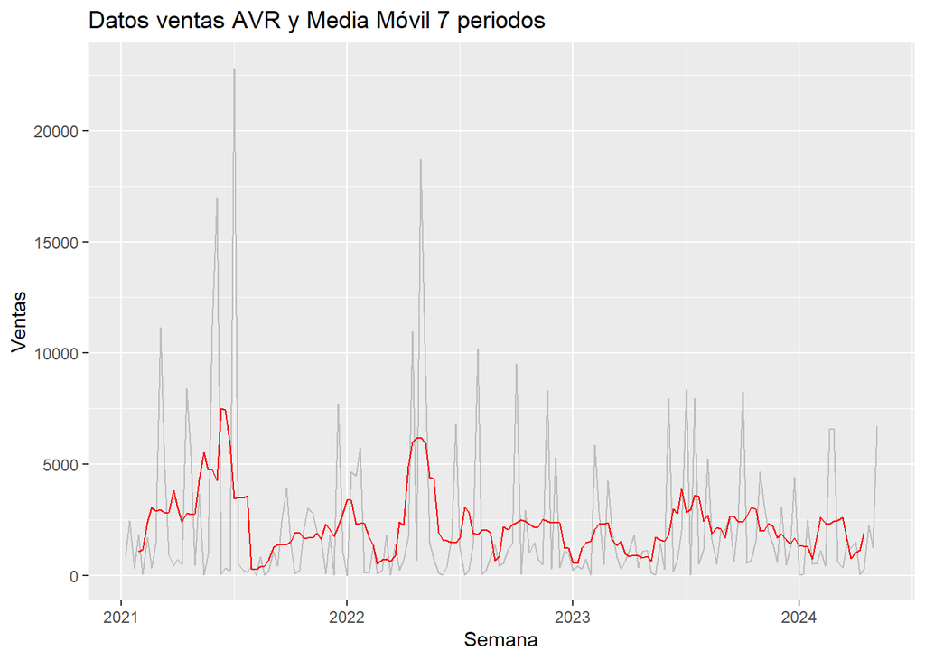

```r
# Convertir a serie de tiempo
AVR_ts <- ts(datos_grupo$AVR, start = c(2021, 2), frequency = 52)

# plot
autoplot(AVR_ts, series = "AVR" , color = "gray") + ylab("Ventas") + xlab("Semana")+
  autolayer(ma(AVR_ts,7), series = "7-SMA", color = "red")+
  ggtitle("Datos ventas AVR y Media Móvil 7 periodos")
```

Los datos de ventas de Line UPS tienen picos menos extremos que en AVR, con un máximo alrededor de 12,500. La serie es más constante.

La media móvil sigue una tendencia ligeramente descendente en 2021, estabilizándose después con fluctuaciones menos pronunciadas.

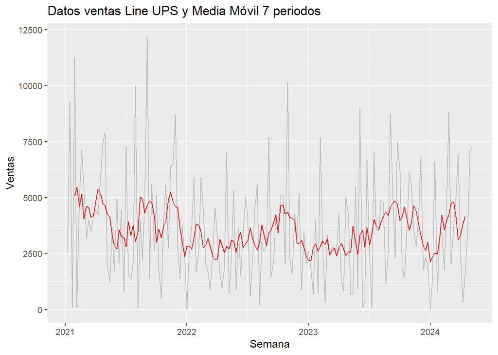

```r
# Convertir a serie de tiempo
Line_UPS_ts <- ts(datos_grupo$Line_UPS, start = c(2021, 2), frequency = 52)

# plot
autoplot(Line_UPS_ts, series = "AVR" , color = "gray") + ylab("Ventas") + xlab("Semana")+
  autolayer(ma(Line_UPS_ts,7), series = "7-SMA", color = "red")+
  ggtitle("Datos ventas Line UPS y Media Móvil 7 periodos")
```

El gráfico de ventas de Online UPS muestra valores de ventas mucho menores en comparación con AVR y Line UPS, con picos que apenas superan los 600. La serie tiene fluctuaciones más regulares y moderadas.

La media móvil es más estable, aunque sigue algunas oscilaciones a lo largo del tiempo.

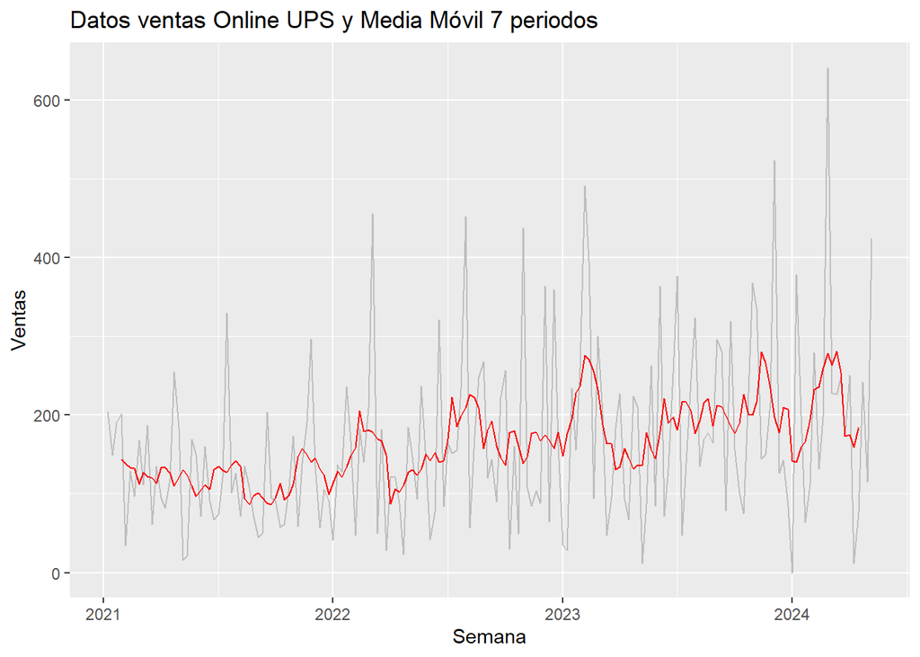

```r
# Convertir a serie de tiempo
Online_UPS_ts <- ts(datos_grupo$Online_UPS, start = c(2021, 2), frequency = 52)

# plot
autoplot(Online_UPS_ts, series = "AVR" , color = "gray") + ylab("Ventas") + xlab("Semana")+
  autolayer(ma(Online_UPS_ts,7), series = "7-SMA", color = "red")+
  ggtitle("Datos ventas Online UPS y Media Móvil 7 periodos")
```

La media móvil sigue los aumentos a partir de 2023, mostrando una tendencia al alza con mayor estabilidad hacia 2024.

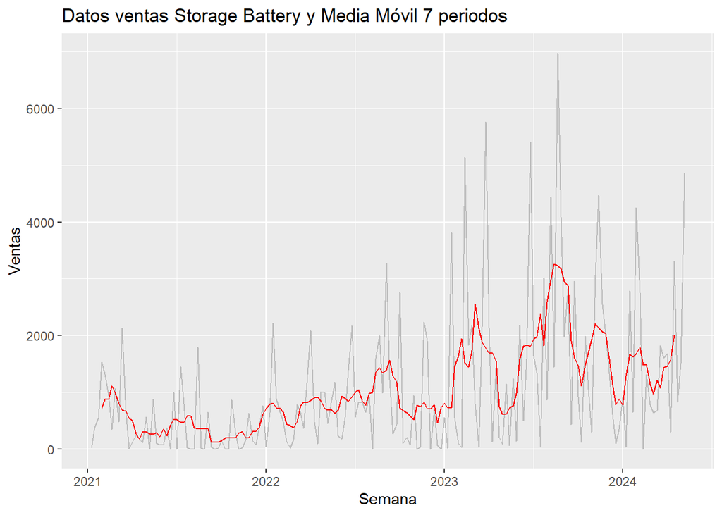

```r
# Convertir a serie de tiempo
Storage_Battery_ts <- ts(datos_grupo$Storage_Battery, start = c(2021, 2), frequency = 52)

# plot
autoplot(Storage_Battery_ts, series = "AVR" , color = "gray") + ylab("Ventas") + xlab("Semana")+
  autolayer(ma(Storage_Battery_ts,7), series = "7-SMA", color = "red")+
  ggtitle("Datos ventas Storage Battery y Media Móvil 7 periodos")
```

### Rezagos

Los gráficos de los rezagos presentados a continuación no muestran una tendencia o una correlación claramente.

Particularmente en los grupos AVR y Storage Battery presentan acumulaciones de puntos en el punto 0 debido a que estos dos grupos particularmente tienen una mayor de registros en ceros.

Para los grupos Line UPS y Online UPS los datos presentan un comportamiento disperso.

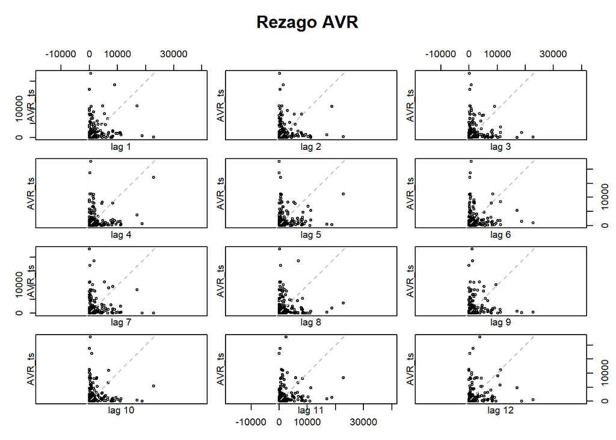

```r
# lag plot grafica de rezagos
lag.plot(AVR_ts, 12, main = "Rezago AVR", do.lines = FALSE)
```

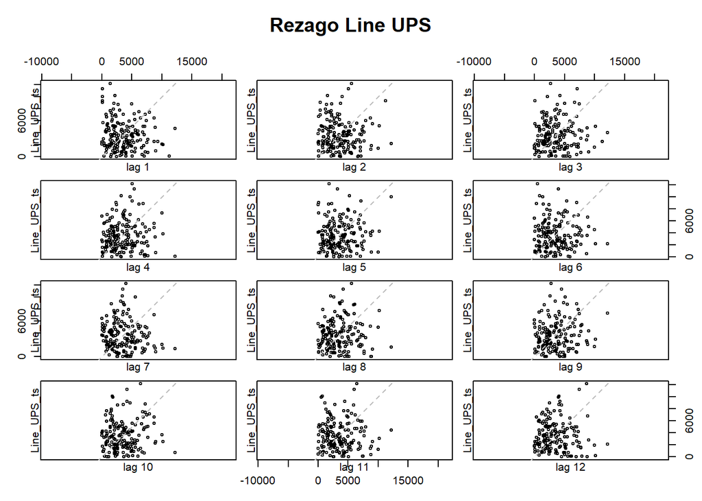

```r
# lag plot grafica de rezagos
lag.plot(Line_UPS_ts, 12, main = "Rezago Line UPS", do.lines = FALSE)
```

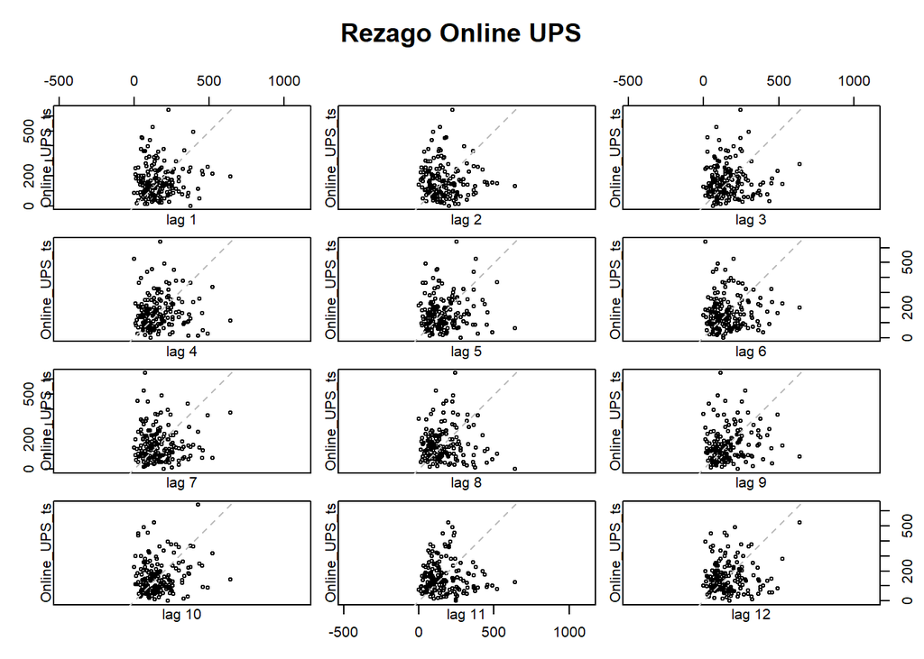

```r
# lag plot grafica de rezagos
lag.plot(Online_UPS_ts, 12, main = "Rezago Online UPS", do.lines = FALSE)
```

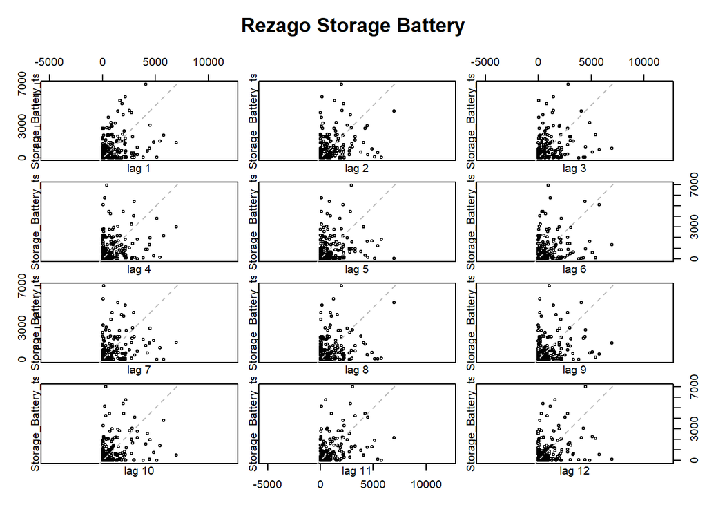

```r
# lag plot grafica de rezagos
lag.plot(Storage_Battery_ts, 12, main = "Rezago Storage Battery", do.lines = FALSE)
```

### Estacionalidad

Para los datos de AVR se observan comportamiento identificable con picos pronunciados entre las semanas 25 y 29 en 3 de los 4 años de estudio.

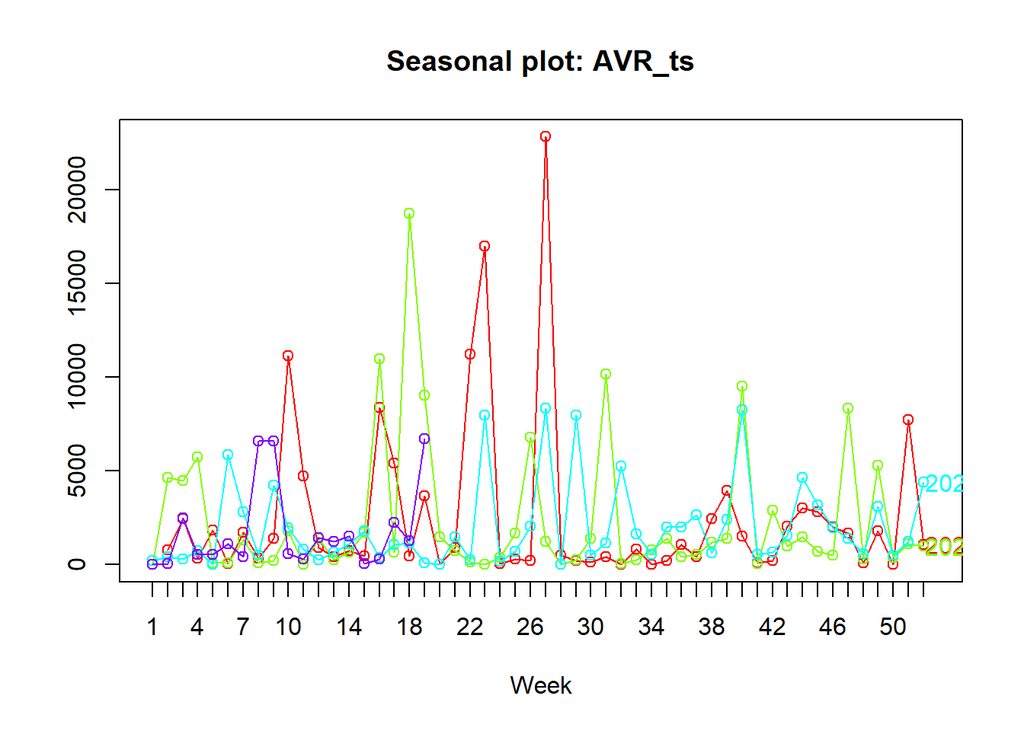

```r
seasonplot(AVR_ts,
           col = rainbow(4),
           year.labels = TRUE)
```

Para el grupo de items Line UPS se alcanza a identificar un comportamiento similar entre los datos mostrando un fenómeno de estacionalidad entre las semanas 35 y 37.

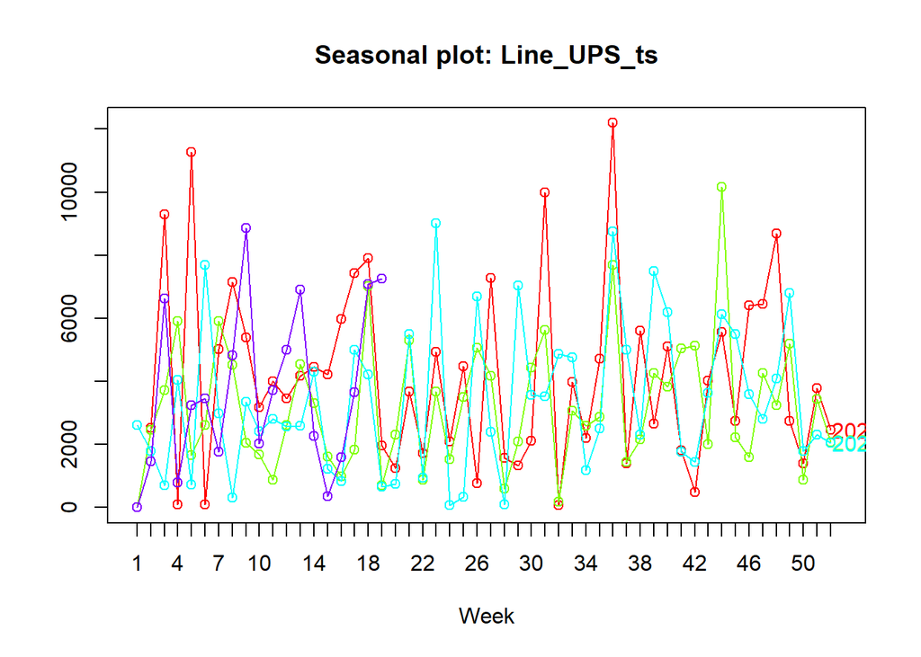

```r
seasonplot(Line_UPS_ts,
           col = rainbow(4),
           year.labels = TRUE)
```

Para el grupo de items de Online UPS no se alcanza a identificar patrones marcados, los datos parecen presentar un fenómeno de aleatoriedad en los datos.

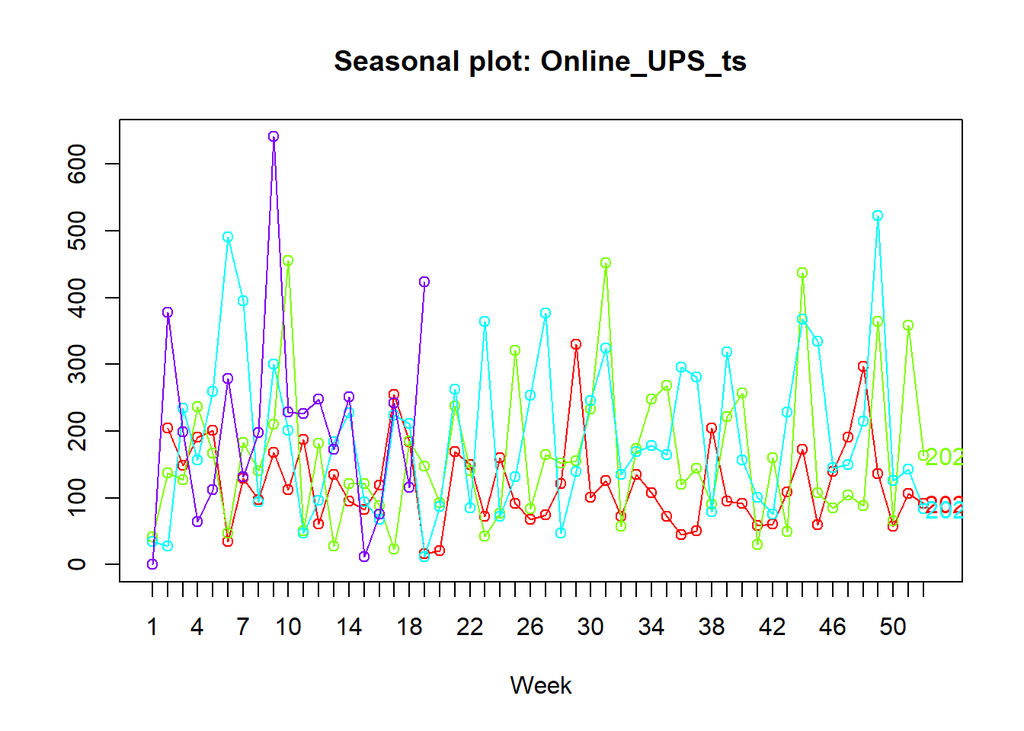

```r
seasonplot(Online_UPS_ts,
           col = rainbow(4),
           year.labels = TRUE)
```

Para el grupo de items de Storage battery no se alcanza a identificar patrones marcados, los datos parecen presentar un fenómeno de aleatoriedad en los datos.

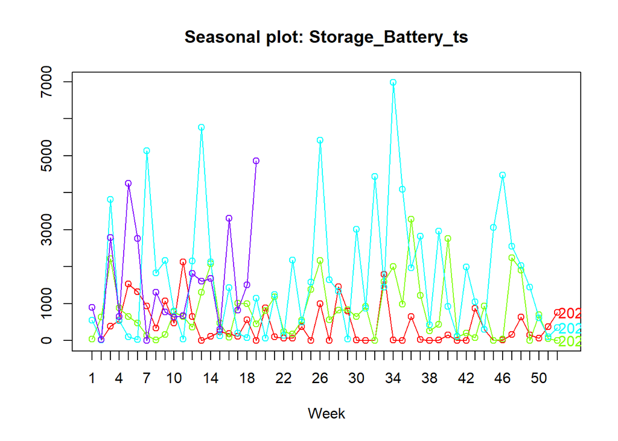

```r
seasonplot(Storage_Battery_ts,
           col = rainbow(4),
           year.labels = TRUE)
```